## Dplyr

```r
setwd("~/Desktop/intro2r/")
```

- need to load csv surveys
- fot those not in last class, need to down load data from intro2r

```r
#download.file("http://files.figshare.com/2236372/combined.csv", "data/portal_data_joined.csv")
surveys <- read.csv("data/portal_data_joined.csv")
```

- Packages in R are sets of additional functions

```r
#install.packages("dplyr") ## install
```

- Choose a CRAN mirror

```r
library("dplyr")          ## load
```

- `dplyr` provides tools for the most common data manipulation tasks
- faster `plyr` - written in C
- besides working with flat files, can work with external DBs
- `dplyr` functions: `select()`,`filter()`, `mutate()`, `group_by()`, and `summarize()`
- select selects columns to keep

```r
# surveys[, c(5,6,9)]
select(surveys, plot_id, species_id, weight)
```

- choose rows with `filter`

```r
#surveys[surveys$year == 1995]
filter(surveys, year == 1995)
```

### Pipes

- allows chaining functions togther
- uses `%>%` as a pipe - from the `magrittr` package installed as part of `dplyr`
- Takes the output of one function and send it directly to the next

```r
#filter(select(surveys, c(species, sex, weight)), weight < 5)
surveys %>%
  filter(weight < 5) %>%
  select(species_id, sex, weight)
```

```
##    species_id sex weight
## 1          PF   F      4
## 2          PF   F      4
## 3          PF   M      4
## 4          RM   F      4
## 5          RM   M      4
## 6          PF          4
## 7          PP   M      4
## 8          RM   M      4
## 9          RM   M      4
## 10         RM   M      4
## 11         PF   M      4
## 12         PF   F      4
## 13         RM   M      4
## 14         RM   M      4
## 15         RM   F      4
## 16         RM   M      4
## 17         RM   M      4
```

- assign to a new object

```r
surveys_sml <- surveys %>%
  filter(weight < 5) %>%
  select(species_id, sex, weight)

surveys_sml
```

### Challenge

> Using pipes, subset the data to include rows before 1995. Retain columns `year`, `sex`, and `weight.`

```r
surveys %>%
  filter(year < 1995) %>%
  select(year, sex, weight)
```

### Mutate

- create new columns based on the values in existing columns
- e.g. unit conversions or find the ratio of values in two columns

```r
#weight is in grams
surveys %>%
  mutate(weight_kg = weight / 1000)
```

- a new column of weight in kg (let’s look `head(surveys)`)

```r
surveys %>%
  mutate(weight_kg = weight / 1000)
```

```r
surveys %>%
  mutate(weight_kg = weight / 1000)
```

- first few rows are full of NAs

```r
surveys %>%
  mutate(weight_kg = weight / 1000) %>%
  filter(!is.na(weight)) %>%
  head
```

```
##   record_id month day year plot_id species_id sex hindfoot_length weight
## 1       588     2  18 1978       2         NL   M              NA    218
## 2       845     5   6 1978       2         NL   M              32    204
## 3       990     6   9 1978       2         NL   M              NA    200
## 4      1164     8   5 1978       2         NL   M              34    199
## 5      1261     9   4 1978       2         NL   M              32    197
## 6      1453    11   5 1978       2         NL   M              NA    218
##     genus  species   taxa plot_type weight_kg
## 1 Neotoma albigula Rodent   Control     0.218
## 2 Neotoma albigula Rodent   Control     0.204
## 3 Neotoma albigula Rodent   Control     0.200
## 4 Neotoma albigula Rodent   Control     0.199
## 5 Neotoma albigula Rodent   Control     0.197
## 6 Neotoma albigula Rodent   Control     0.218
```

### Split-apply-combine

```r
surveys %>%
  group_by(sex) %>%
  tally()
```

```
## Source: local data frame [6 x 2]
##
##      sex     n
##   (fctr) (int)
## 1         1743
## 2      F 15690
## 3      M 17348
## 4      P     1
## 5      R     3
## 6      Z     1
```

- `group_by()` is often used together with `summarize()` which collapses each group

```r
surveys %>%
  group_by(sex) %>%
  summarize(mean_weight = mean(weight, na.rm = TRUE))
```

- You can group by multiple columns too:

```r
surveys %>%
  group_by(sex, species_id) %>%
  summarize(mean_weight = mean(weight, na.rm = TRUE))
```

```r
surveys %>%
  group_by(sex, species_id) %>%
  summarize(mean_weight = mean(weight, na.rm = TRUE)) %>%
  filter(!is.nan(mean_weight))
```

```
## Source: local data frame [66 x 3]
## Groups: sex [5]
##
##       sex species_id mean_weight
##    (fctr)     (fctr)       (dbl)
## 1                 DM    38.28571
## 2                 DO    50.66667
## 3                 DS   120.00000
## 4                 NL   167.68750
## 5                 OL    29.00000
## 6                 OT    21.20000
## 7                 PB    30.60000
## 8                 PE    17.66667
## 9                 PF     6.00000
## 10                PI    18.00000
## ..    ...        ...         ...
```

- note: abve `dplyr` has changed our `data.frame` to a `tbl_df` more concise output
- summarize multiple variables at the same time:

```r
surveys %>%
  group_by(sex, species_id) %>%
  summarize(mean_weight = mean(weight, na.rm = TRUE),
            min_weight = min(weight, na.rm = TRUE)) %>%
  filter(!is.nan(mean_weight))
```

```
## Source: local data frame [66 x 4]
## Groups: sex [5]
##
##       sex species_id mean_weight min_weight
##    (fctr)     (fctr)       (dbl)      (int)
## 1                 DM    38.28571         24
## 2                 DO    50.66667         44
## 3                 DS   120.00000         78
## 4                 NL   167.68750         83
## 5                 OL    29.00000         21
## 6                 OT    21.20000         18
## 7                 PB    30.60000         20
## 8                 PE    17.66667         17
## 9                 PF     6.00000          4
## 10                PI    18.00000         18
## ..    ...        ...         ...        ...
```

### Challenge

```r
surveys %>%
  group_by(plot_id) %>%
  tally
```

```
## Source: local data frame [24 x 2]
##
##    plot_id     n
##      (int) (int)
## 1        1  1989
## 2        2  2191
## 3        3  1808
## 4        4  1960
## 5        5  1150
## 6        6  1562
## 7        7   729
## 8        8  1881
## 9        9  1929
## 10      10   324
## ..     ...   ...
```

### Challenge

> Use `group_by()` and `summarize()` to find the mean, min, and max hindfoot length for each species.

```r
surveys %>%
  group_by(species_id) %>%
  summarize(mean_hindfoot = mean(hindfoot_length, na.rm = TRUE),
            min_hindfoot = min(hindfoot_length, na.rm = TRUE),
            max_hindfoot = max(hindfoot_length, na.rm = T)) %>%
  filter(!is.nan(mean_hindfoot))
```

```
## Source: local data frame [25 x 4]
##
##    species_id mean_hindfoot min_hindfoot max_hindfoot
##        (fctr)         (dbl)        (int)        (int)
## 1          AH      33.00000           31           35
## 2          BA      13.00000            6           16
## 3          DM      35.98235           16           50
## 4          DO      35.60755           26           64
## 5          DS      49.94887           39           58
## 6          NL      32.29423           21           70
## 7          OL      20.53261           12           39
## 8          OT      20.26741           13           50
## 9          OX      19.12500           13           21
## 10         PB      26.11592            2           47
## ..        ...           ...          ...          ...
```

### Challenge

> What was the heaviest animal measured in each year? Return the columns `year`, `genus`, `species`, and `weight`.

## ggplot2

*basic ploting capabilities are available in basic R, but ggplot2 adds more powerful plotting

```r
# plotting package
library(ggplot2)
# piping / chaining
library(magrittr)
# modern dataframe manipulations
library(dplyr)
```

- load data directly from figshare.

```r
surveys_raw <- read.csv("http://files.figshare.com/1919744/surveys.csv")
```

- `surveys.csv` data contains some measurements of the animals caught in plots.
- let’s look at in a file
- summary

```r
summary(surveys_raw)
```

```
##    record_id         month             day             year
##  Min.   :    1   Min.   : 1.000   Min.   : 1.00   Min.   :1977
##  1st Qu.: 8888   1st Qu.: 4.000   1st Qu.: 9.00   1st Qu.:1984
##  Median :17775   Median : 6.000   Median :16.00   Median :1990
##  Mean   :17775   Mean   : 6.474   Mean   :16.11   Mean   :1990
##  3rd Qu.:26662   3rd Qu.: 9.000   3rd Qu.:23.00   3rd Qu.:1997
##  Max.   :35549   Max.   :12.000   Max.   :31.00   Max.   :2002
##
##     plot_id       species_id    sex       hindfoot_length     weight
##  Min.   : 1.0   DM     :10596    : 2506   Min.   : 2.00   Min.   :  4.00
##  1st Qu.: 5.0   PP     : 3123   F:15690   1st Qu.:21.00   1st Qu.: 20.00
##  Median :11.0   DO     : 3027   M:17348   Median :32.00   Median : 37.00
##  Mean   :11.4   PB     : 2891   P:    1   Mean   :29.29   Mean   : 42.67
##  3rd Qu.:17.0   RM     : 2609   R:    3   3rd Qu.:36.00   3rd Qu.: 48.00
##  Max.   :24.0   DS     : 2504   Z:    1   Max.   :70.00   Max.   :280.00
##                 (Other):10799             NA's   :4111    NA's   :3266
```

```r
#add-on packages will have more complete descriptive stats
#stat.desc(surveys) #from pastecs
#surveys_raw$species_id
```

- step 1 - we need to clean the dataset
- missing `species_id` in some records we need to remove

```r
surveys <- surveys_raw %>%
           filter(species_id != "")
```

- many species with low counts, let’s remove the ones below 10 counts
- try `table(surveys_raw$species_id)` to get a nice count

```r
# count records per species
species_counts <- surveys %>%
                  group_by(species_id) %>%
                  tally

# get names of those frequent species
frequent_species <- species_counts %>%
                    filter(n >= 10) %>%
                    select(species_id)

#use frequent_species to filter surveys
surveys <- surveys %>%
           filter(species_id %in% frequent_species$species_id)
```

```r
summary(surveys)
```

```
##    record_id         month             day             year
##  Min.   :    1   Min.   : 1.000   Min.   : 1.00   Min.   :1977
##  1st Qu.: 8944   1st Qu.: 4.000   1st Qu.: 9.00   1st Qu.:1984
##  Median :17750   Median : 6.000   Median :16.00   Median :1990
##  Mean   :17794   Mean   : 6.475   Mean   :16.09   Mean   :1990
##  3rd Qu.:26650   3rd Qu.:10.000   3rd Qu.:23.00   3rd Qu.:1997
##  Max.   :35548   Max.   :12.000   Max.   :31.00   Max.   :2002
##
##     plot_id        species_id    sex       hindfoot_length
##  Min.   : 1.00   DM     :10596    : 1694   Min.   : 2.0
##  1st Qu.: 5.00   PP     : 3123   F:15685   1st Qu.:21.0
##  Median :11.00   DO     : 3027   M:17333   Median :32.0
##  Mean   :11.34   PB     : 2891   P:    1   Mean   :29.3
##  3rd Qu.:17.00   RM     : 2609   R:    3   3rd Qu.:36.0
##  Max.   :24.00   DS     : 2504   Z:    1   Max.   :70.0
##                  (Other): 9967             NA's   :3300
##      weight
##  Min.   :  4.00
##  1st Qu.: 20.00
##  Median : 37.00
##  Mean   : 42.69
##  3rd Qu.: 48.00
##  Max.   :280.00
##  NA's   :2454
```

- summary shows NA’s in weight and hindfoot_length – Let’s remove rows with missing weights.

```r
surveys_weight_present <- surveys %>%
                      filter(!is.na(weight))
```

### Challenge

> - Do the same to remove rows without `hindfoot_length`. Save results in the new dataframe.

```r
surveys_length_present <- surveys %>%
                      filter(!is.na(hindfoot_length))
```

- How would you get the dataframe without missing values?

```r
surveys_complete <- surveys_weight_present %>%
                    filter(!is.na(hindfoot_length))
```

> We can chain filtering together using pipe operator (`%>%`) introduced earlier.

```r
surveys_complete <- surveys %>%
                    filter(!is.na(weight)) %>%
                    filter(!is.na(hindfoot_length))
```

> Make simple scatter plot of `hindfoot_length` (in millimeters) as a function of `weight` (in grams), using basic R plotting capabilities.

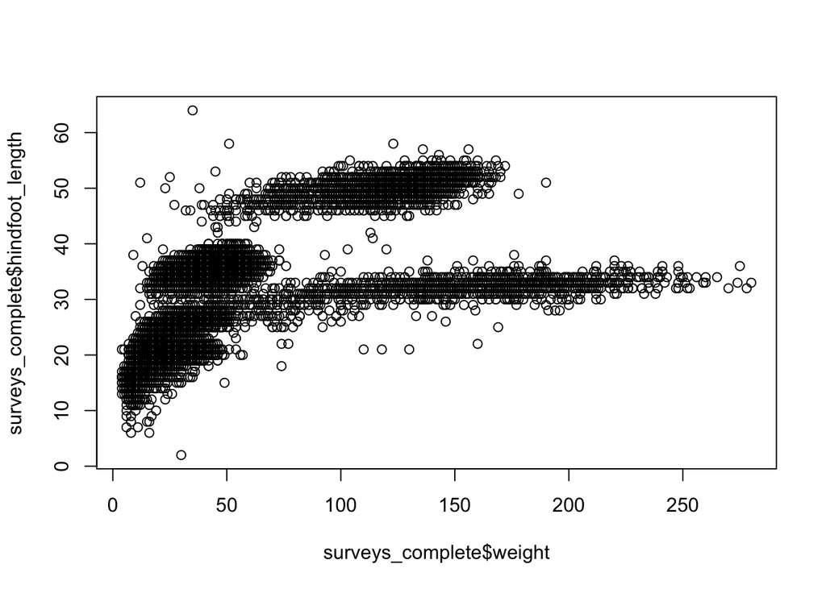

```r
plot(x=surveys_complete$weight, y=surveys_complete$hindfoot_length)
```

## Plotting with ggplot2

- make the same plot using `ggplot2` package.
- `ggplot2` is a plotting package that makes it easier to create complex plots
- implements a grammar of graphics, so we can build up plots
- ggplot requires:
1. bind plot to a specific data frame

```r
ggplot(surveys_complete)
```

2. define aestetics (`aes`), that maps variables in the data to axes on the plot or to plotting size, shape color, etc.,

```r
ggplot(surveys_complete, aes(x = weight, y = hindfoot_length))
```

3. add `geoms` – graphical representation of the data in the plot (points, lines, bars). To add a geom to the plot use `+` operator:

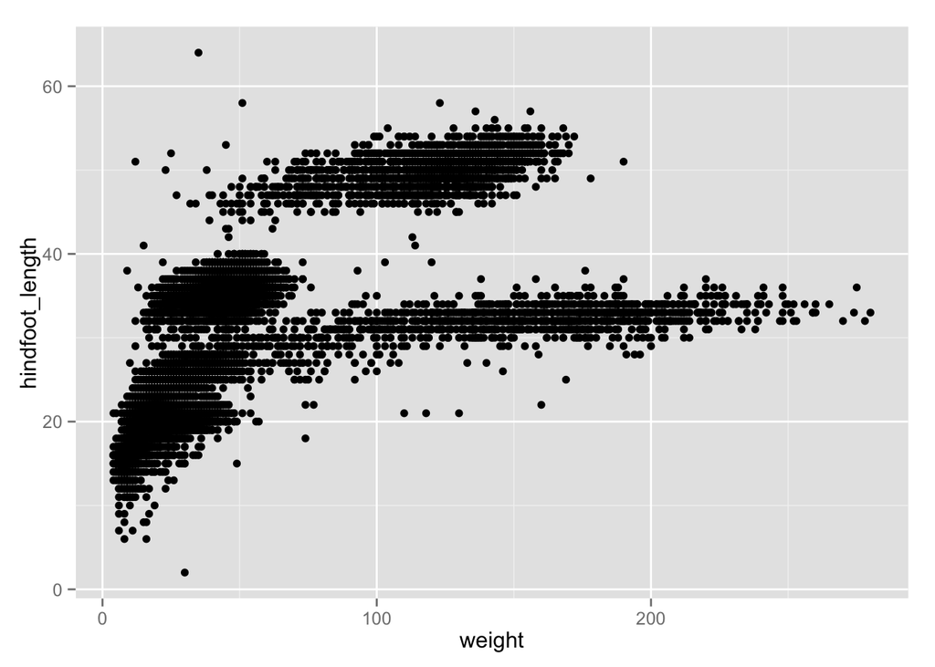

```r
ggplot(surveys_complete, aes(x = weight, y = hindfoot_length)) +
  geom_point()
```

## Modifying plots

- adding transparency (alpha)

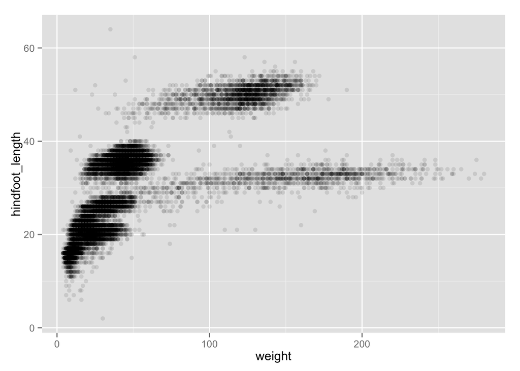

```r
ggplot(surveys_complete, aes(x = weight, y = hindfoot_length)) +
  geom_point(alpha=0.1)
```

- adding colors

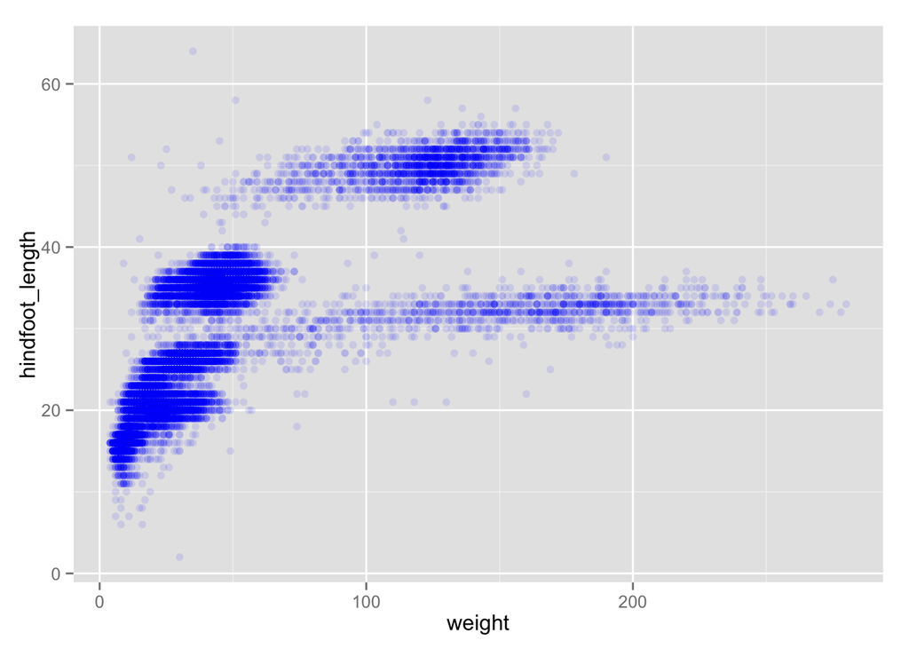

```r
ggplot(surveys_complete, aes(x = weight, y = hindfoot_length)) +
  geom_point(alpha=0.1, color="blue")
```

## Boxplot

- Visualising the distribution of weight within each species.

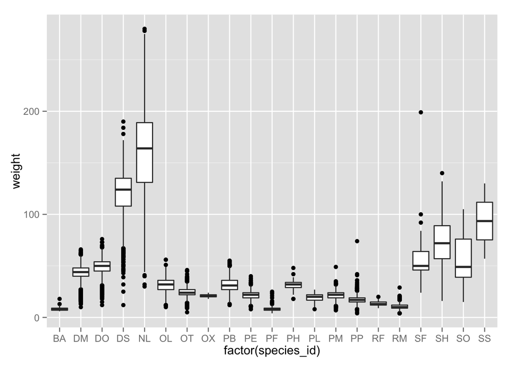

```r
ggplot(surveys_weight_present, aes(factor(species_id), weight)) +
                   geom_boxplot()
```

- adding points to boxplot and a jitter

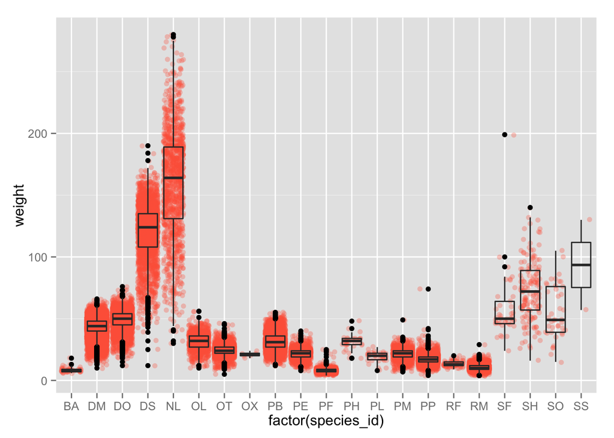

```r
ggplot(surveys_weight_present, aes(factor(species_id), weight)) +
                   geom_jitter(alpha=0.3, color="tomato") +
                   geom_boxplot(alpha=0)
```

### Challenge

> Create boxplot for `hindfoot_length`.

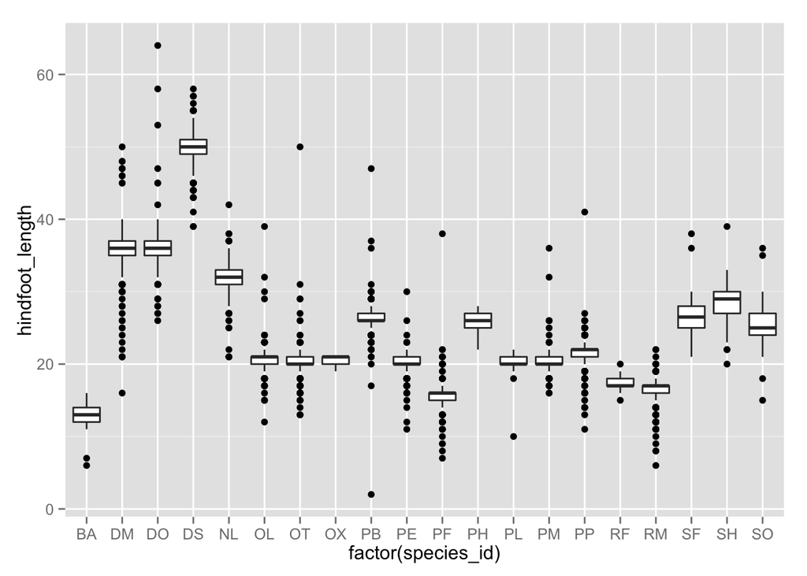

```r
ggplot(surveys_complete, aes(factor(species_id), hindfoot_length)) +
  geom_boxplot()
```

## Time series

- counts per year for each species (group data first and count records within each group)

```r
yearly_counts <- surveys %>%
                 group_by(year, species_id) %>%
                 tally
```

- Timelapse data can be visualised as a line plot with years on x axis and counts on y.

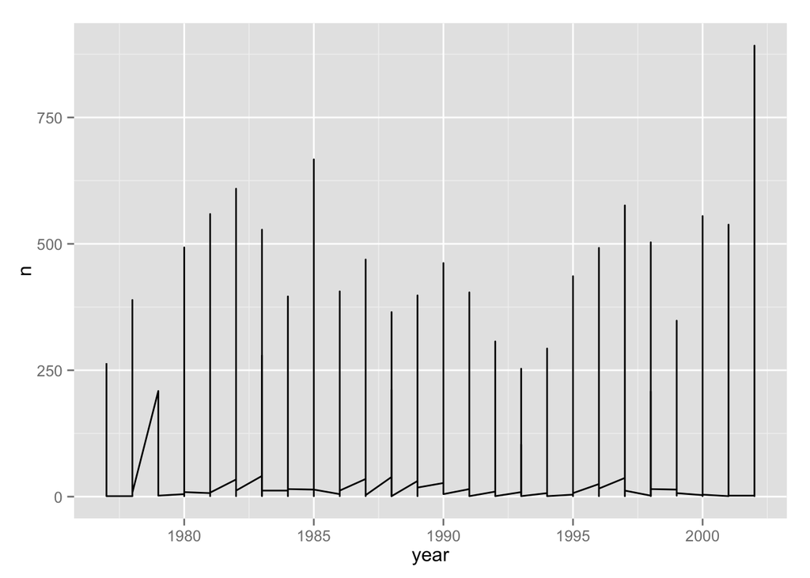

```r
ggplot(yearly_counts, aes(x=year, y=n)) +
                  geom_line()
```

- does not work – plots data for all the species together
- need to ggplot to split graphed data by `species_id`

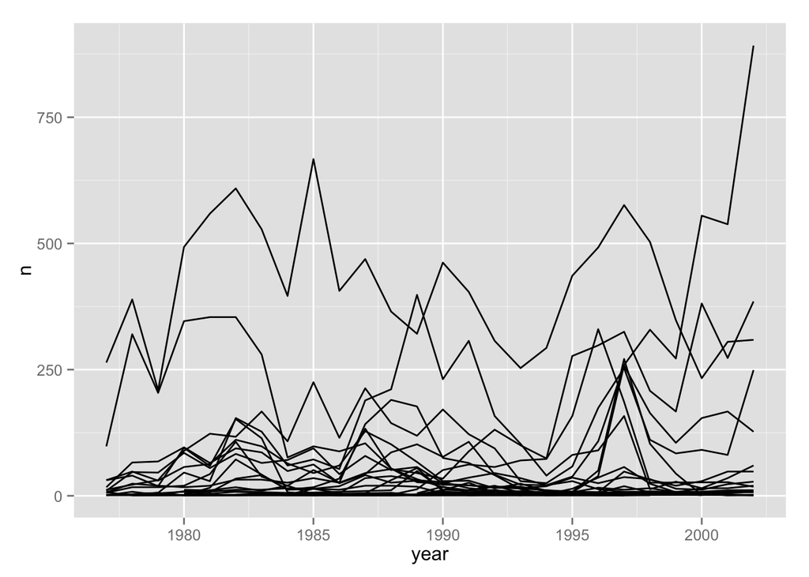

```r
ggplot(yearly_counts, aes(x=year, y=n, group=species_id)) +
  geom_line()
```

- add colors to distinguish species

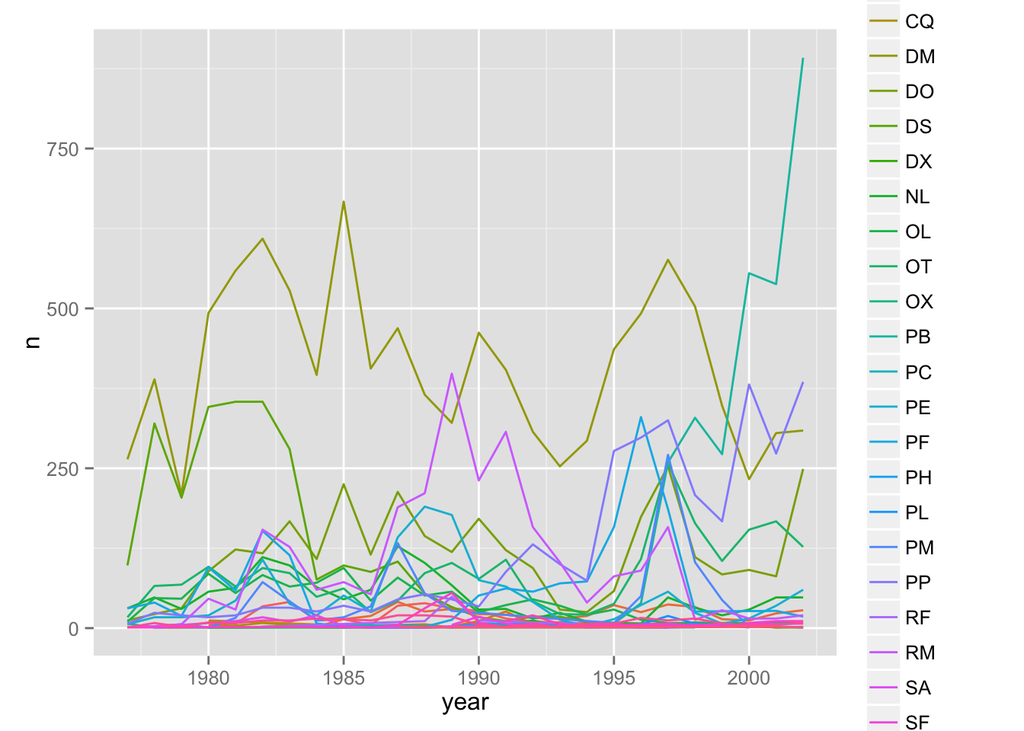

```r
ggplot(yearly_counts, aes(x=year, y=n, group=species_id, color=species_id)) +
  geom_line()
```

## Faceting

- allows to split one plot into mutliple plots based on some factor

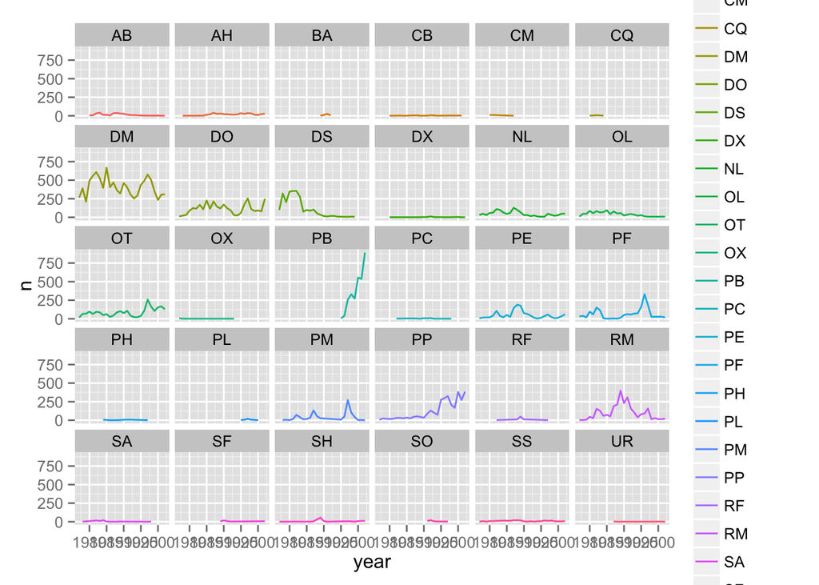

```r
ggplot(yearly_counts, aes(x=year, y=n, color=species_id)) +
  geom_line() + facet_wrap(~species_id)
```

- we want to two lines each plot by sex
- make counts in dataframe grouped by sex.

### Challenges:

> - filter the dataframe so that we only keep records with sex “F” or “M”s

```r
sex_values = c("F", "M")
surveys <- surveys %>%
           filter(sex %in% sex_values)
```

> - group by year, species_id, sex

```r
yearly_sex_counts <- surveys %>%
                     group_by(year, species_id, sex) %>%
                     tally
```

> - make the faceted plot spliting further by sex (within single plot)

```
## geom_path: Each group consist of only one observation. Do you need to adjust the group aesthetic?
```

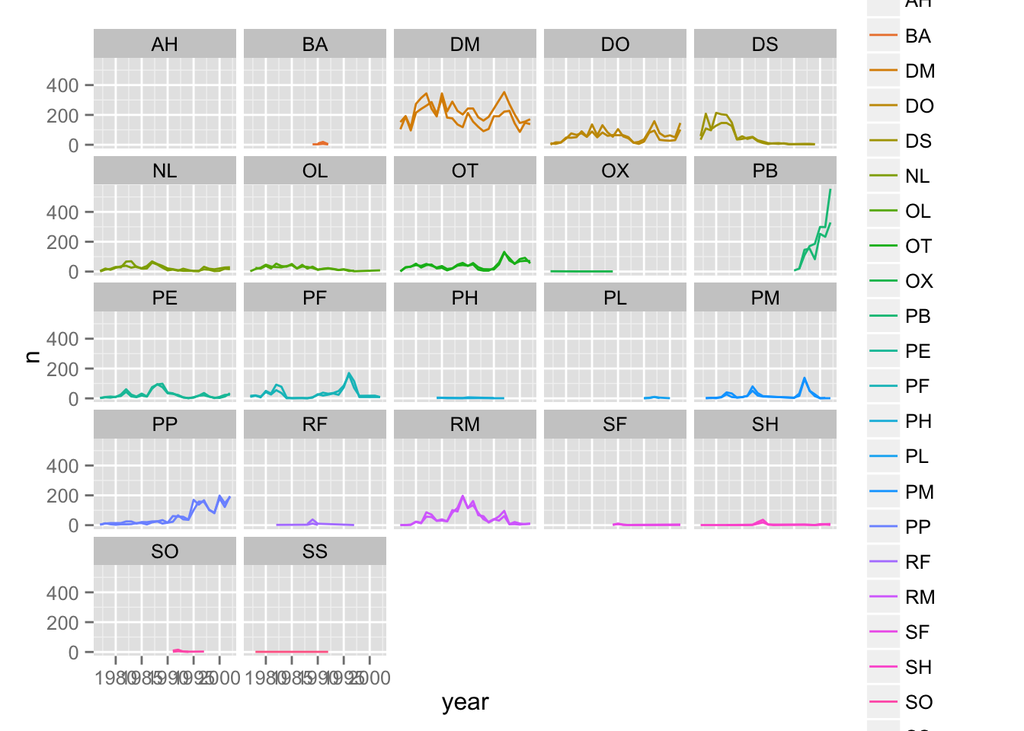

```r
ggplot(yearly_sex_counts, aes(x=year, y=n, color=species_id, group=sex)) +
  geom_line() + facet_wrap(~ species_id)
```

> We can improve the plot by coloring by sex instead of species (species are already in separate plots, so we don’t need to distinguish them better)

```
## geom_path: Each group consist of only one observation. Do you need to adjust the group aesthetic?
```

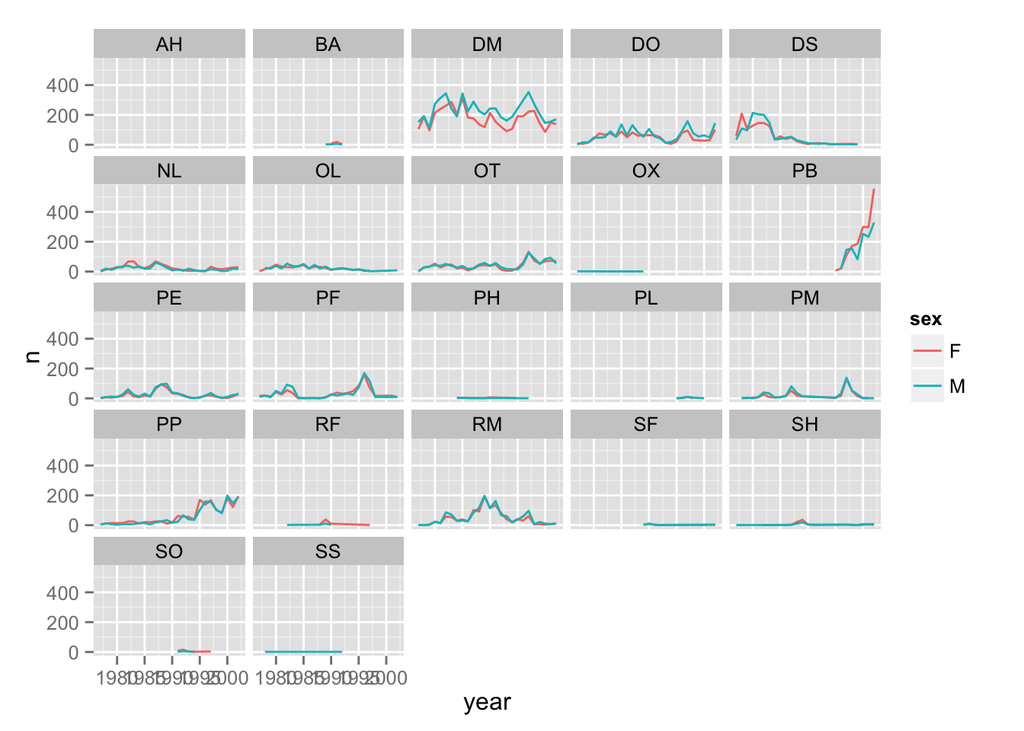

```r
ggplot(yearly_sex_counts, aes(x=year, y=n, color=sex, group=sex)) +
  geom_line() + facet_wrap(~ species_id)
```